# Analiza studije razumijevanja riječi

3 May 2017

# Opis eksperimenta

Nad velikim brojem ispitanika proveden je eksperiment razumijevanja engleskog jezika. Ispitanicima su dana dva zadatka te su oba ponavljana više puta. Prvi zadatak (dalje: **A**) bavi se prepoznavanjem ispravne riječi, prilikom čega je ispitanik za zadani niz znakova morao odrediti radi li se o ispravnoj riječi engleskog jezika, a drugi zadatak (dalje: **B**) se bavi pravilnim izgovaranjem zadane riječi. Za svaku riječ i svakog ispitanika mjereno je vrijeme rješavanja svakog zadatka, te niz podataka o ispitaniku.

## Ishodi eksperimenta

Cilj eksperimenta je naučiti kako mjerene veličine ispitanika utječu na vrijeme potrebno za rješavanje pojedinih zadataka. Na temelju tih podataka može se odgovoriti na neka zanimljiva pitanja poput: utječe li dob na brzinu rješavanja zadataka, kako na brzinu rješavanja utječe duljina zadane riječi, je li riječ kraća ukoliko se češće pojavljuje, itd.

# Skup podataka

Za određivanje ishoda eksperimenta potreban nam je skup podataka eksperimenta. Programski jezik R sadrži skup podataka već provedenog eksperimenta te nam dopušta uključivanje tog skupa te analizu podataka. Podaci se nalaze u paketu `languageR`. Nakon instaliranja paketa, podaci se mogu učitati naredbom `require(languageR)` te dohvatiti s naredbom `data(english)`. Kompletno dohvaćanje i uključivanje podataka prikazano je kodom ispod.

```r
require(languageR, quietly = TRUE)
data(english)
```

Podaci se sada mogu koristiti naredbom `english`, npr. deskriptivna statistika može se dobiti naredbom `summary(english)`, a pregled prvih par redova podataka može se pregledati naredbom `head(english)`.

# Ishodi eksperimenta

## Deskriptivna statistika najbitnijih značajki

```r
#summary(english)
summary(english$AgeSubject)
```

```
##   old young
##  2284  2284
```

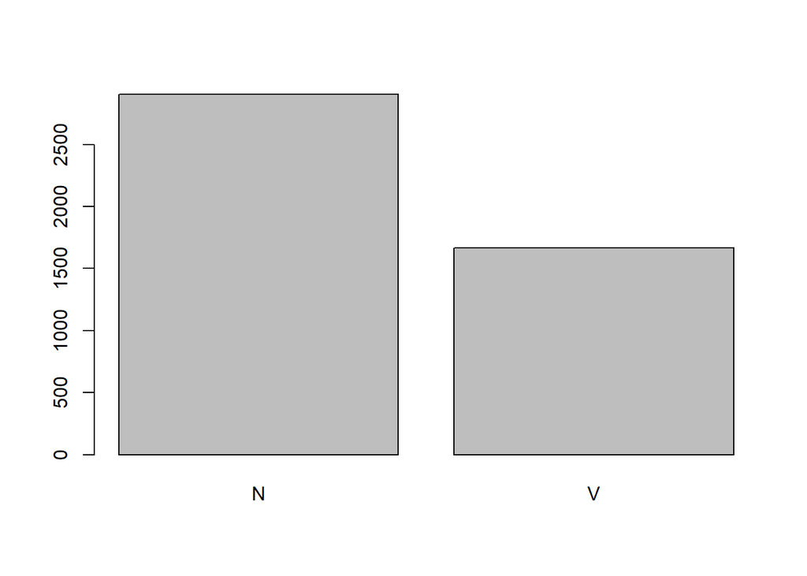

```r
plot(english$WordCategory)
```

```r
#head(english)
```

## Utjecaj dobi na brzinu rješavanja

Pitamo se utječe li dobna razlika između starijih i mlađih ispitanika na brzinu rješavanja zadataka? Uspoređujući srednje vrijednosti logaritama vremena za rješavanje A i B zadataka mlađih i starijih ispitanika te gledajući dijagrame, možemo zaključiti da su mlađi u prosjeku brže rješavali oba zadatka. *t-testom* potvrđujemo naš zaključak.

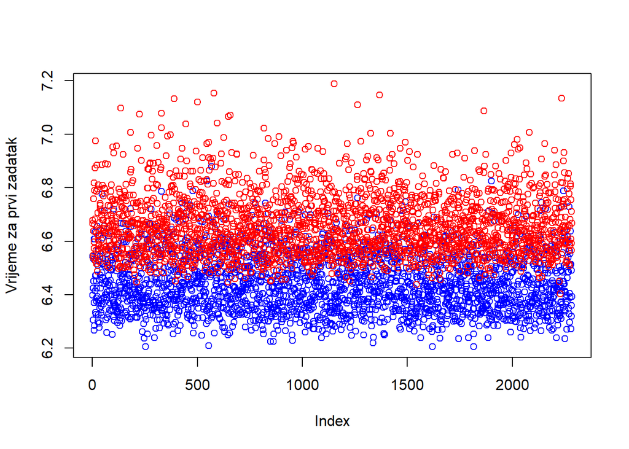

```r
young = english[english$AgeSubject == "young", ] # mladi
old = english[english$AgeSubject == "old", ] # stari

 # vrijeme potrebno mlađima za rješavanje prvog zadatka
RTlexdec_young = young[, "RTlexdec"]

 # vrijeme potrebno starijima za rješavanje prvog zadatka
RTlexdec_old = old[, "RTlexdec"]

 # vrijeme potrebno mlađima za rješavanje drugog zadatka
RTnaming_young = young[, "RTnaming"]

 # vrijeme potrebno starijima za rješavanje drugog zadatka
RTnaming_old = old[, "RTnaming"]

plot(RTlexdec_young, col = 'blue',
     ylim = c(min(english$RTlexdec), max(english$RTlexdec)),
     ylab = "Vrijeme za prvi zadatak")

points(RTlexdec_old, col='red')
```

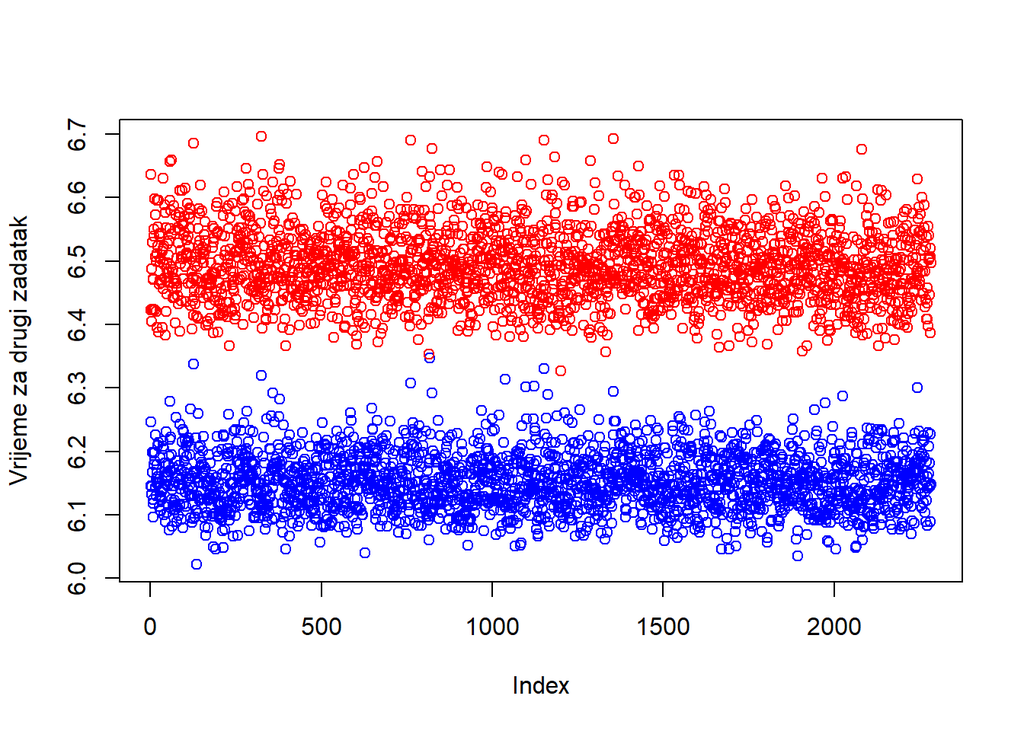

```r
plot(RTnaming_young, col = 'blue',
     ylim = c(min(english$RTnaming), max(english$RTnaming)),
     ylab = "Vrijeme za drugi zadatak")

points(RTnaming_old, col='red')
```

```r
# testiranje jednakosti varijance prije t-testa
var.test(RTlexdec_young, RTlexdec_old)
```

```
##
##  F test to compare two variances
##
## data:  RTlexdec_young and RTlexdec_old
## F = 0.84625, num df = 2283, denom df = 2283, p-value = 6.737e-05
## alternative hypothesis: true ratio of variances is not equal to 1
## 95 percent confidence interval:
##  0.7795831 0.9186270
## sample estimates:
## ratio of variances
##          0.8462542
```

```r
t.test(RTlexdec_young, RTlexdec_old, alt = "two.sided", var.equal = FALSE)
```

```
##
##  Welch Two Sample t-test
##
## data:  RTlexdec_young and RTlexdec_old
## t = -67.468, df = 4534.6, p-value < 2.2e-16
## alternative hypothesis: true difference in means is not equal to 0
## 95 percent confidence interval:
##  -0.2281642 -0.2152787
## sample estimates:
## mean of x mean of y
##  6.439237  6.660958
```

## Prepoznatljivost riječi s obzirom na frekvenciju pojavljivanja

Zanima nas jesu li riječi koje se više pojavljuje prepoznatljivije? Računamo korelaciju između prepoznatljivosti riječi i njenog pojavljivanja u tekstovima. Dobivamo korelaciju `~0.8`, što nam potvrđuje da su te dvije stavke povezane, tj. riječi koje se više pojavljuju su prepoznatljivije. To također vidimo i iz dijagrama rasipanja.

```r
cor(english$Familiarity, english$WrittenFrequency)
```

```
## [1] 0.7912556
```

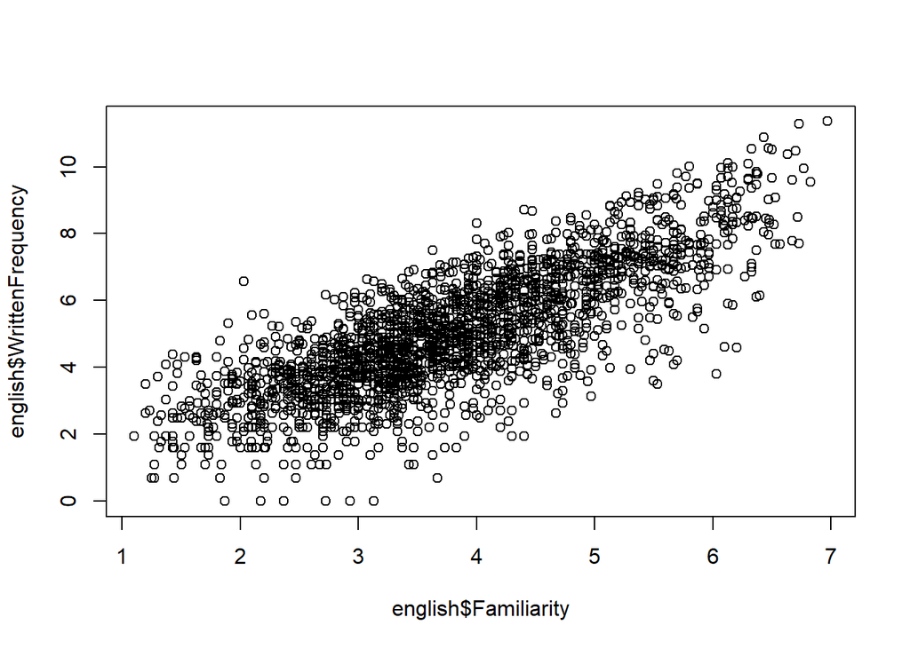

```r
plot(english$Familiarity, english$WrittenFrequency)
```

## Utjecaj glasa prvog slova na prepoznatljivost riječi

```r
firstVowel = english[english$CV == "V",] #riječi koje počinju sa samoglasnikom
firstConsonant = english[english$CV == "C",] # riječi koje počinju sa suglasnikom

mean(firstConsonant$Familiarity)
```

```
## [1] 3.789892
```

```r
mean(firstVowel$Familiarity)
```

```
## [1] 4.002951
```

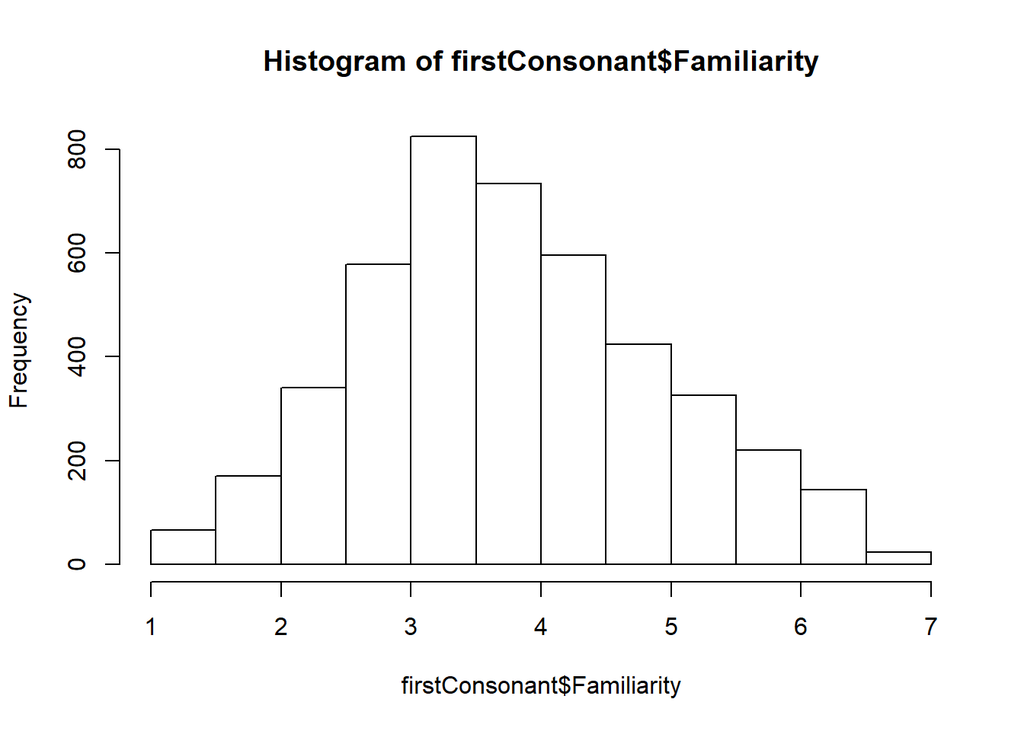

```r
hist(firstConsonant$Familiarity)
```

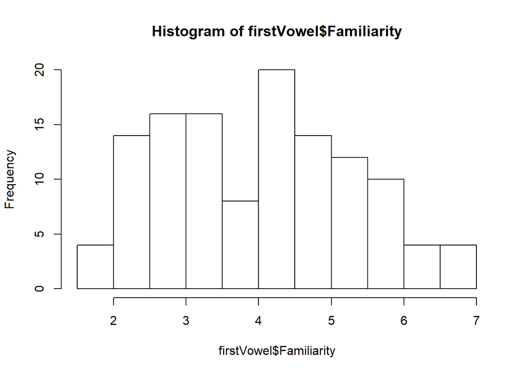

```r
hist(firstVowel$Familiarity)
```

```r
# prije testiranja t-testom trebamo zaključiti jesu li varijance jednake u oba slučaja
var.test(firstConsonant$Familiarity, firstVowel$Familiarity)
```

```
##
##  F test to compare two variances
##
## data:  firstConsonant$Familiarity and firstVowel$Familiarity
## F = 0.78386, num df = 4445, denom df = 121, p-value = 0.04732
## alternative hypothesis: true ratio of variances is not equal to 1
## 95 percent confidence interval:
##  0.5971133 0.9971773
## sample estimates:
## ratio of variances
##          0.7838635
```

```r
t.test(firstVowel$Familiarity, firstConsonant$Familiarity, alt = "two.sided", var.equal = TRUE)
```

```
##
##  Two Sample t-test
##
## data:  firstVowel$Familiarity and firstConsonant$Familiarity
## t = 2.0207, df = 4566, p-value = 0.04337
## alternative hypothesis: true difference in means is not equal to 0
## 95 percent confidence interval:
##  0.006350292 0.419767272
## sample estimates:
## mean of x mean of y
##  4.002951  3.789892
```

## Prepoznatljivost glagola u odnosu na imenice

```r
require(BSDA, quietly = TRUE)
verb_familiarity = english[english$WordCategory == "V", ]$Familiarity
noun_familiarity = english[english$WordCategory == "N", ]$Familiarity

verb_sd = sd(english[english$WordCategory == "V", ]$Familiarity)
noun_sd = sd(english[english$WordCategory == "N", ]$Familiarity)

z.test(verb_familiarity, y = noun_familiarity, alternative = "greater", sigma.x = verb_sd, sigma.y = noun_sd)
```

```
##
##  Two-sample z-Test
##
## data:  verb_familiarity and noun_familiarity
## z = 8.5172, p-value < 2.2e-16
## alternative hypothesis: true difference in means is greater than 0
## 95 percent confidence interval:
##  0.24113      NA
## sample estimates:
## mean of x mean of y
##  3.985565  3.686722
```

```r
z.test(noun_familiarity, y = verb_familiarity, alternative = "greater", sigma.x = noun_sd, sigma.y = verb_sd)
```

```
##
##  Two-sample z-Test
##
## data:  noun_familiarity and verb_familiarity
## z = -8.5172, p-value = 1
## alternative hypothesis: true difference in means is greater than 0
## 95 percent confidence interval:
##  -0.3565562         NA
## sample estimates:
## mean of x mean of y
##  3.686722  3.985565
```

## Zavisnost broja pojavljivanja riječi u velikoj zbirci tekstova i duljine riječi

Testiramo nezavisnost na ove dvije varijable i očekujemo da su one povezane jer riječi “i”, “ili”, “ako”, itd. se češće pojavljuju od neke dugačke riječi. Provodimo hi-kvadrat test nezavisnosti s razinom signifikantnosti 5% te dobivamo p-vrijednost manju od 5% i zaključujemo da su te dvije varijable povezane.

```r
chisq.test(english$WrittenFrequency, english$LengthInLetters, simulate.p.value = TRUE)
```

```
##
##  Pearson's Chi-squared test with simulated p-value (based on 2000
##  replicates)
##
## data:  english$WrittenFrequency and english$LengthInLetters
## X-squared = 11681, df = NA, p-value = 0.0004998
```

## Logistička regresija

Učimo modele logističke regresije da predviđaju varijablu WordCategory na temelju prediktorskih varijabli RTlexdec i RTnaming (obje te pojedinačno).

```r
model1 = glm(WordCategory ~ RTlexdec + RTnaming, data = english, family = binomial())
summary(model1)
```

```
##
## Call:
## glm(formula = WordCategory ~ RTlexdec + RTnaming, family = binomial(),
##     data = english)
##
## Deviance Residuals:
##     Min       1Q   Median       3Q      Max
## -1.0552  -0.9643  -0.9219   1.3964   1.6145
##
## Coefficients:
##             Estimate Std. Error z value Pr(>|z|)
## (Intercept)   2.5912     1.3046   1.986  0.04701 *
## RTlexdec     -0.8996     0.3046  -2.953  0.00314 **
## RTnaming      0.4339     0.2661   1.630  0.10301
## ---
## Signif. codes:  0 '***' 0.001 '**' 0.01 '*' 0.05 '.' 0.1 ' ' 1
##
## (Dispersion parameter for binomial family taken to be 1)
##
##     Null deviance: 5991.7  on 4567  degrees of freedom
## Residual deviance: 5982.0  on 4565  degrees of freedom
## AIC: 5988
##
## Number of Fisher Scoring iterations: 4
```

Koristimo test omjera izglednosti da testiramo postoji li značajna razlika u kvaliteti ovih modela. Testirat ćemo postoji li razlika između modela na razini značajnosti 95% tako što ćemo testirati nultu hipotezu da nema razlike. U prvom slučaju nam p-vrijednost ispadne veća od 0.05, pa ne možemo odbaciti nultu hipotezu. U drugom slučaju nam p-vrijednost ispadne manja od 0.05, pa nultu hipotezu odbacujemo. AIC je mjera prilagodbe modela i kod nje manja vrijednost znači bolji model. S obzirom na to da je kod naših modela AIC mjera jako velika, možemo zaključiti da modeli nisu jako dobri.

```r
model2 = glm(WordCategory ~ RTlexdec, data = english, family = binomial())
summary(model2)
```

```
##
## Call:
## glm(formula = WordCategory ~ RTlexdec, family = binomial(), data = english)
##
## Deviance Residuals:
##     Min       1Q   Median       3Q      Max
## -1.0218  -0.9596  -0.9260   1.3977   1.5591
##
## Coefficients:
##             Estimate Std. Error z value Pr(>|z|)
## (Intercept)   2.8646     1.2912   2.219  0.02651 *
## RTlexdec     -0.5225     0.1972  -2.650  0.00805 **
## ---
## Signif. codes:  0 '***' 0.001 '**' 0.01 '*' 0.05 '.' 0.1 ' ' 1
##
## (Dispersion parameter for binomial family taken to be 1)
##
##     Null deviance: 5991.7  on 4567  degrees of freedom
## Residual deviance: 5984.7  on 4566  degrees of freedom
## AIC: 5988.7
##
## Number of Fisher Scoring iterations: 4
```

```r
anova(model1, model2, test= "LRT")
```

```
## Analysis of Deviance Table
##
## Model 1: WordCategory ~ RTlexdec + RTnaming
## Model 2: WordCategory ~ RTlexdec
##   Resid. Df Resid. Dev Df Deviance Pr(>Chi)
## 1      4565     5982.0
## 2      4566     5984.7 -1  -2.6643   0.1026
```

```r
model3 = glm(WordCategory ~ RTnaming, data = english, family = binomial())
summary(model3)
```

```
##
## Call:
## glm(formula = WordCategory ~ RTnaming, family = binomial(), data = english)
##
## Deviance Residuals:
##     Min       1Q   Median       3Q      Max
## -0.9709  -0.9604  -0.9405   1.4094   1.4473
##
## Coefficients:
##             Estimate Std. Error z value Pr(>|z|)
## (Intercept)   0.4868     1.0899   0.447    0.655
## RTnaming     -0.1651     0.1724  -0.958    0.338
##
## (Dispersion parameter for binomial family taken to be 1)
##
##     Null deviance: 5991.7  on 4567  degrees of freedom
## Residual deviance: 5990.8  on 4566  degrees of freedom
## AIC: 5994.8
##
## Number of Fisher Scoring iterations: 4
```

```r
anova(model1, model3, test = "LRT")
```

```
## Analysis of Deviance Table
##
## Model 1: WordCategory ~ RTlexdec + RTnaming
## Model 2: WordCategory ~ RTnaming
##   Resid. Df Resid. Dev Df Deviance Pr(>Chi)
## 1      4565     5982.0
## 2      4566     5990.8 -1  -8.8029 0.003007 **
## ---
## Signif. codes:  0 '***' 0.001 '**' 0.01 '*' 0.05 '.' 0.1 ' ' 1
```

```r
test1 = english[5,]
p1 = predict(model1, test1, type = "response")
p2 = predict(model2, test1, type = "response")
p3 = predict(model3, test1, type = "response")

test2 = english[3055,]
p4 = predict(model1, test2, type = "response")
p5 = predict(model2, test2, type = "response")
p6 = predict(model3, test2, type = "response")

odds1 = p1/(1-p1)
odds2 = p4/(1-p4)
```